# L13

# Probabilistic Models

- Models describe how (a portion of) the world works
- Models are always simplifications
  - May not account for every variable
  - May not account for all interactions between variables

## Probability

### Conditional Independence

- Variables can become independent if you know one of the conditions is true
- eg:

[figure not shown]

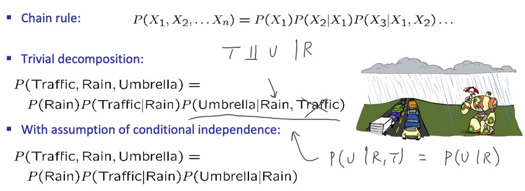

  - Note the necessity of the conditional independence assumption
  - Can be represented with Bayes’ nets

### Bayes’ Nets

- A technique for describing complex joint distributions (models) using simple, local distributions (conditional probabilities)
- Good because sometimes the tables get too big
- Hard to learn full table empirically about tables with more than a few variables
- Type of graph
  - Nodes: variables (with domains)
    - Can be assigned (observed) or unassigned (unobserved)
  - Arcs: interactions
    - Similar to CSP constraints
    - Indicate ‘direct influence’ between variables
    - Formally: encode conditional independence
- Given a set of nodes, one per variable $X$, it is a directed, acyclic graph with a conditional distribution for each node
  - A collection of distributions over $X$, one for each combination of parents’ values: $\mathbb{P}(X|a_{1},{\dots}a_{n})$
  - CPT: conditional probability table
- To see what probability a BN gives to a full assignment, multiply all the relevant conditionals together: $\mathbb{P}(x_{1},x_{2},{\dots},x_{n})=\prod_{i=1}^{n}\mathbb{P}(x_{i}|\mathrm{parents}(X_{i}))$
  - Good because it assumes conditional independence

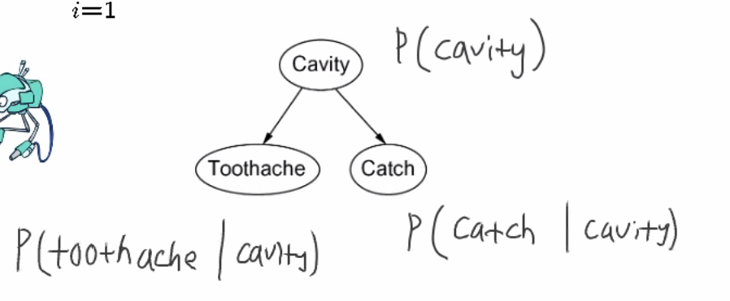